# Studie zum Aufwand für einen CO2-freien Energiesektor in China bis 2050

Region: China + Planetare Belastungsgrenze: Klima

Zhuo et al. (2022)

In der Studie wird berechnet, wieviel erneuerbare Energien nötig sind, um China 2050 komplett CO2-neutral zu versorgen, und welche Kosten das verursacht. Quelle/Hinweis: (Davidson, 2022) -> Hitzewelle führt zur Steigerung der Kohleproduktion in China

Pressemeldung/Beschreibung mit den wichtigsten Inhalten: [Paper Published in Nature Communications by GEIDCO Jointly with Tsinghua University and Harvard University - 全球能源互联网发展合作组织](https://m.geidco.org.cn/pcarticle/4454)

Parameter:

Jährliche CO2-Emissionen jetzt: 4.5 Milliarden Tonnen (über 50% Kohle, 2019 62.1%)

Kosten der Dekarbonisierung der Energiesystems bis 2050: 7.31 Billionen USD (50,4 Billionen CNY) Kosten des Business as Usual-Szenarios: 4.55 Billionen USD (31.4 Billionen CNY)

Abbildung:

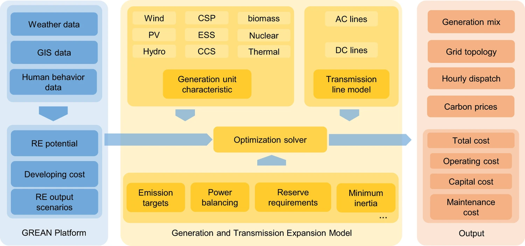

We generate the typical year-round hourly output data for renewable energy (RE) plants and summarize the supply curves for each province based on the Global Renewable-energy Exploitation Analysis (GREAN) database. The generation and transmission expansion (GTEP) model, an optimization problem solver, simulates future power system developments. The hourly RE output intermittency, the characteristics of various generation technologies, and system security requirements are all considered. The impacts of high RE penetration are analyzed based on the solution results.

Quelle: [Fig. 1: Modelling framework for generation and transmission expansion optimization. | Nature Communications](https://www.nature.com/articles/s41467-022-30747-0/figures/1)

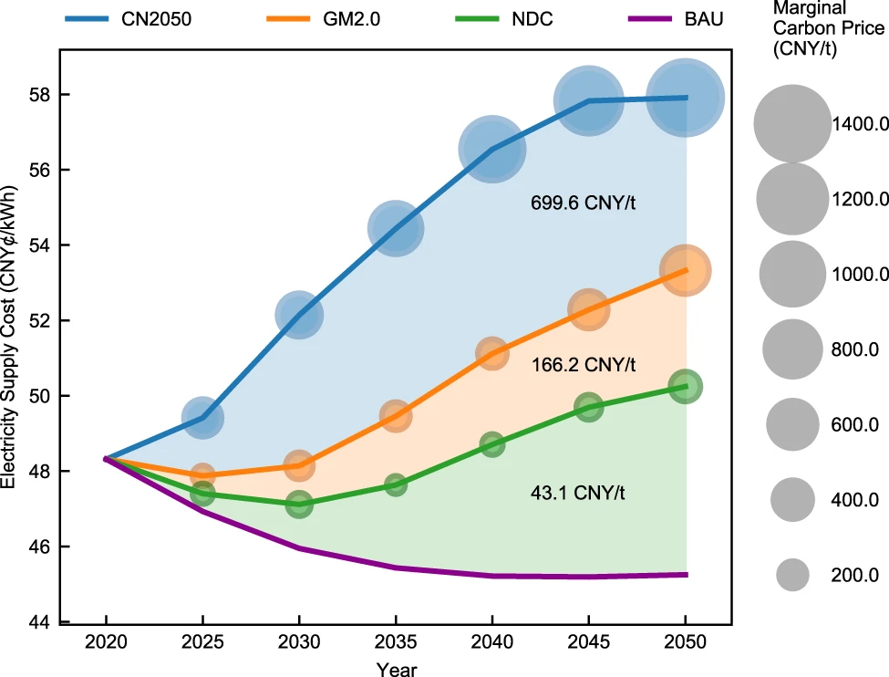

The four scenarios include the Carbon neutrality (CN2050) scenario, Global Warming of 2.0 <sup>∘</sup>C (GM2.0) scenario, Nationally Determined Contribution (NDC) scenario and Business-as-usual (BAU) scenario. The electricity supply cost is the average cost the power system must pay to supply per kWh of load demand. The marginal carbon price is the increased power system cost per tonne of carbon reduction based on the emission target each year. From the perspective of an optimization problem, the marginal carbon prices are the shadow prices of carbon emission constraints and can be obtained directly by solving the GTEP model. Their calculation does not need a reference case. The marginal carbon price in the BAU scenario is zero because no carbon emission constraints are considered. The number between each pair of curves denotes the average carbon mitigation cost per tonne between the more stringent scenario and the less stringent one. This value is numerically equal to the ratio of the difference in the total costs of the two scenarios and the difference between the carbon emission budget.

Quelle: [Fig. 7: Electricity supply costs and carbon mitigation costs under four different scenarios. | Nature Communications](https://www.nature.com/articles/s41467-022-30747-0/figures/7)

VRE: Variable Renewable Energy

Die jährlichen Zusatzkosten für die komplette Dekarbonisierung betragen 0,62% des chinesischen Bruttosozialprodukts

Davidson, H. (2022, June 24). Chinese premier calls for more coal production as electricity demand soars. *The Guardian*. https://www.theguardian.com/world/2022/jun/24/chinese-premier-calls-for-more-coal-production-as-electricity-demand-soars

Zhuo, Z., Du, E., Zhang, N., Nielsen, C. P., Lu, X., Xiao, J., Wu, J., & Kang, C. (2022). Cost increase in the electricity supply to achieve carbon neutrality in China. *Nature Communications*, *13*(1), 3172. https://doi.org/10.1038/s41467-022-30747-0